[figure not shown]

# District of Columbia, District of Columbia

## Driver: Strong and Healthy Families

### Domain: Financial Well-Being

*Visit here for a thorough description of the metrics in this domain.*

#### Predictor: Income

##### Summary

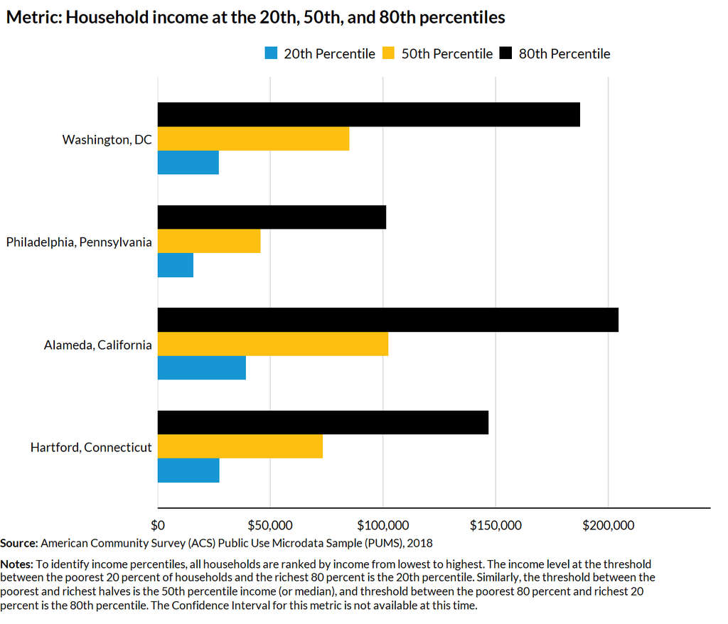

##### Subgroup

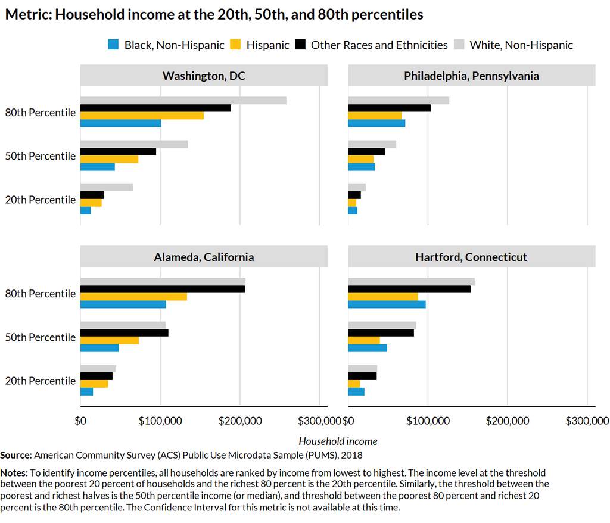

#### Predictor: Financial security

##### Summary

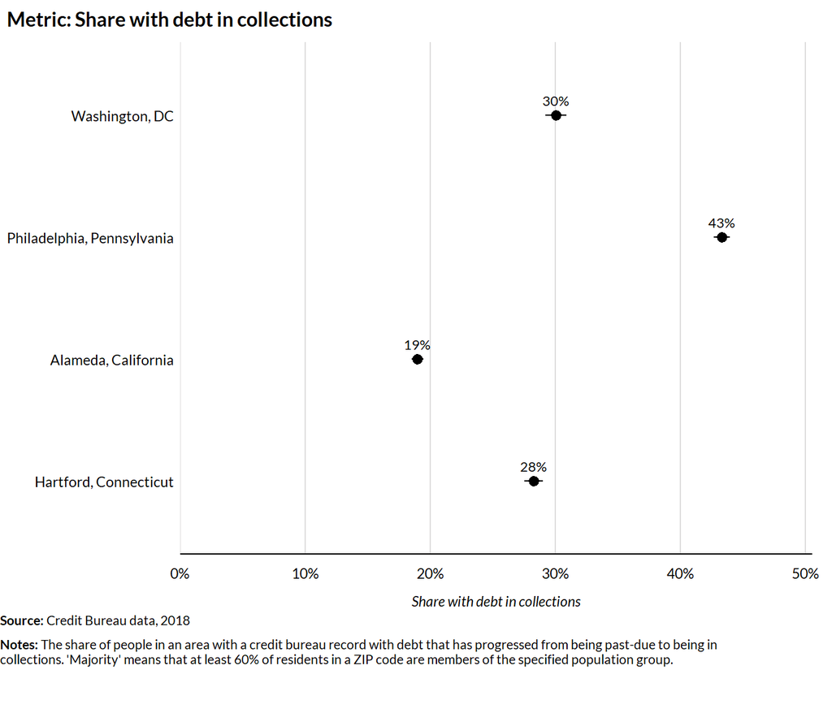

##### Sub-Area

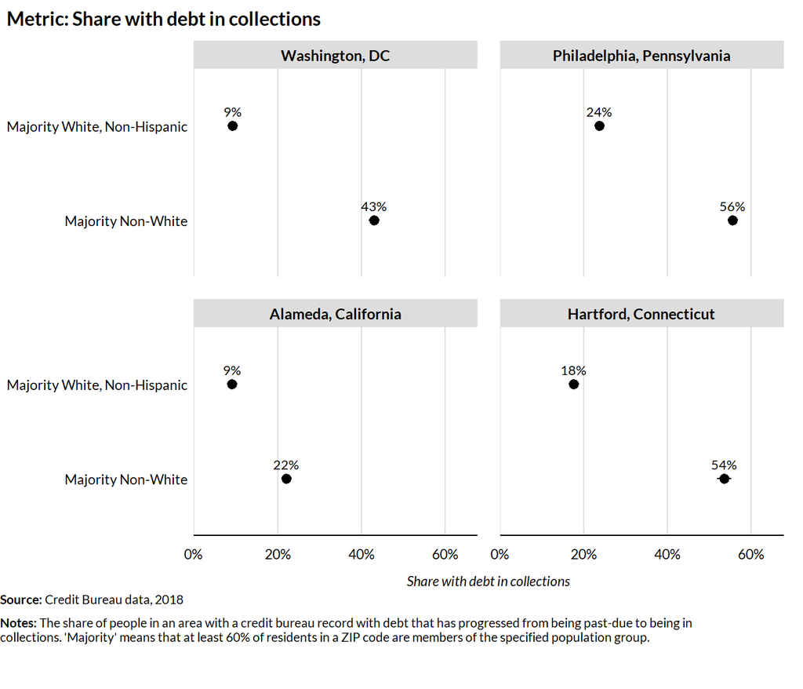

### Domain: Secure and Stable Housing

*Visit here for a thorough description of the metrics in this domain.*

#### Predictor: Affordable housing

##### Summary

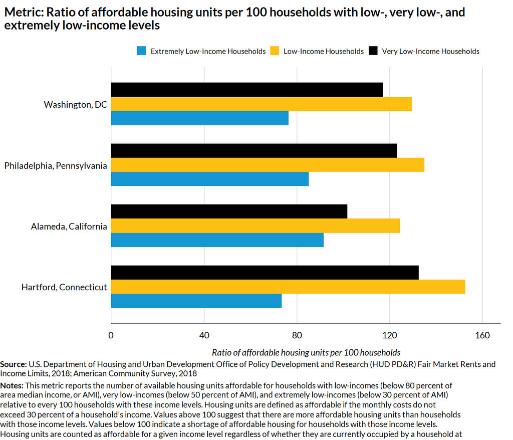

##### More Years

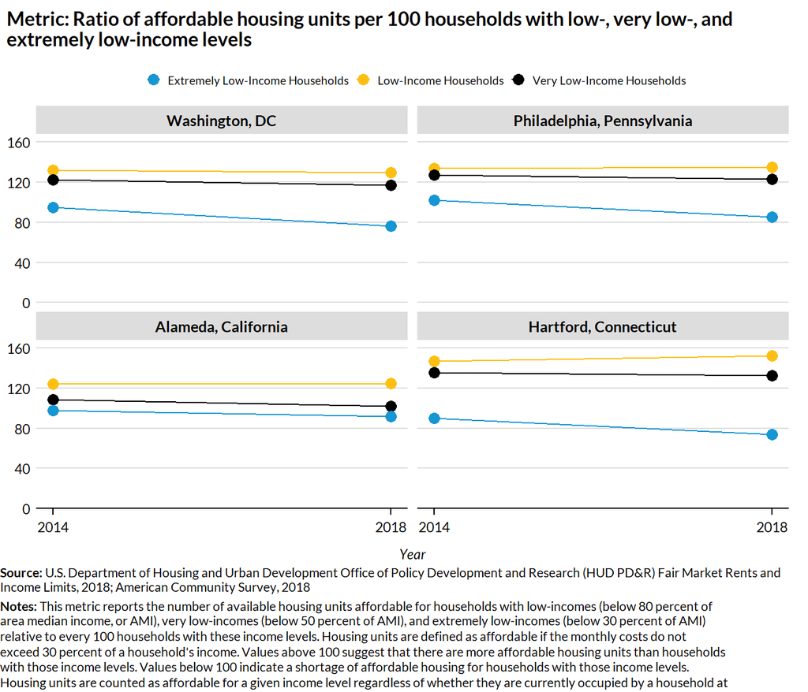

#### Predictor: Affordable housing

##### Summary

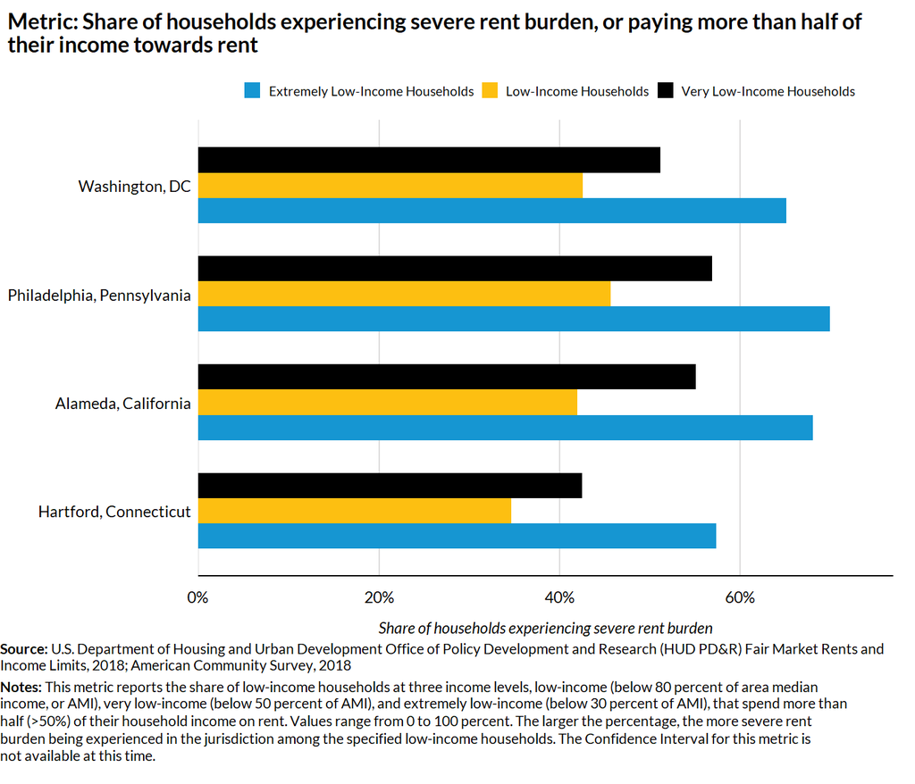

##### More Years

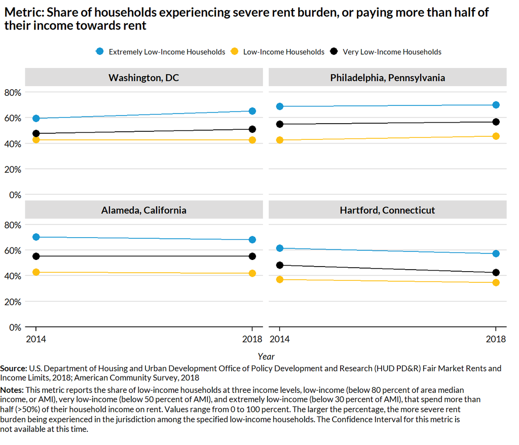

#### Predictor: Housing instability and homelessness

##### Summary

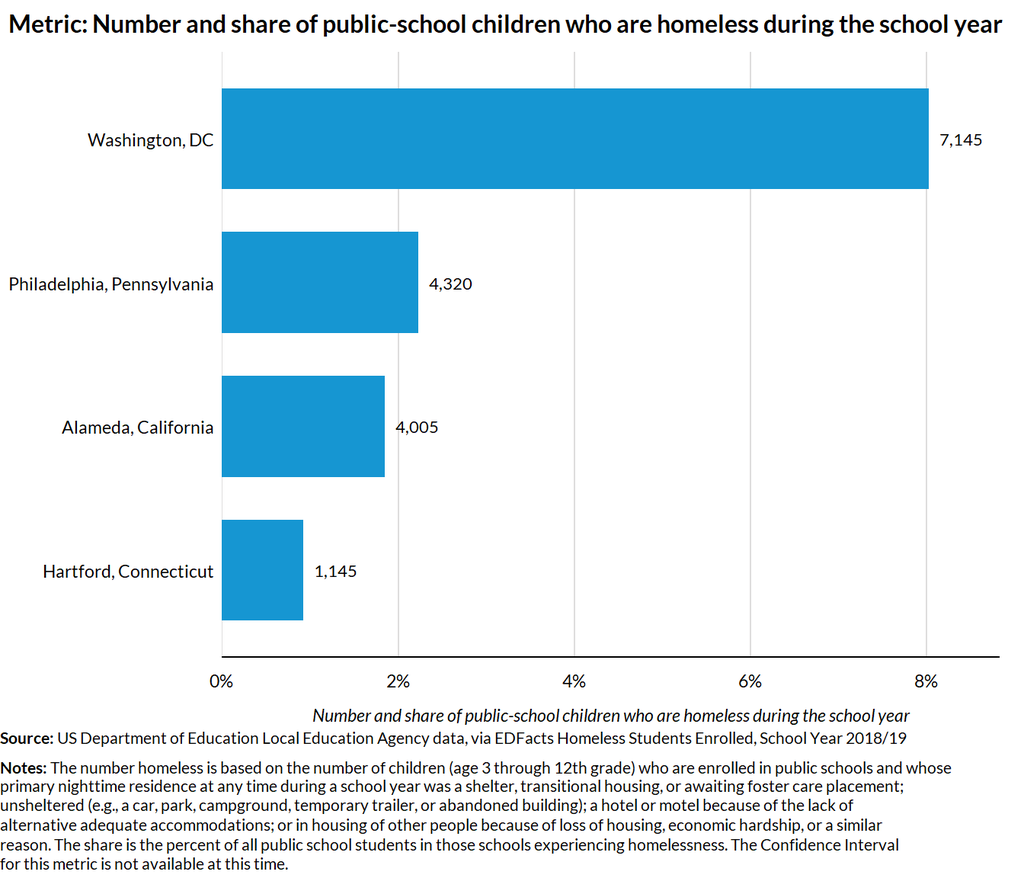

##### More Years

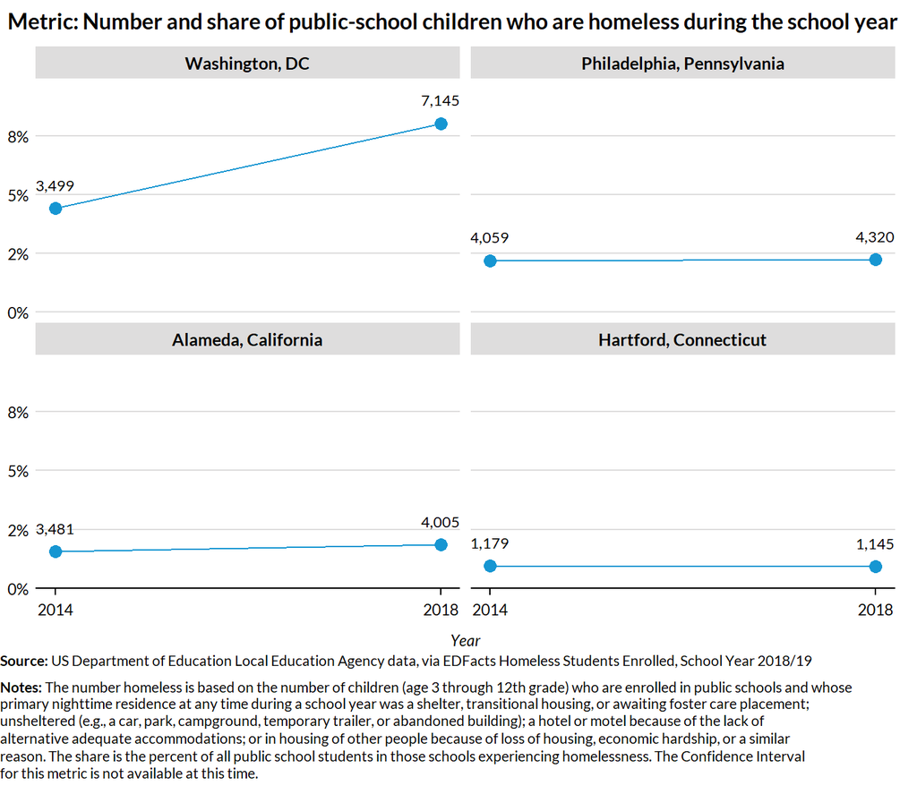

### Domain: Family Stability

*Visit here for a thorough description of the metrics in this domain.*

#### Predictor: Family structure and stability

##### Summary

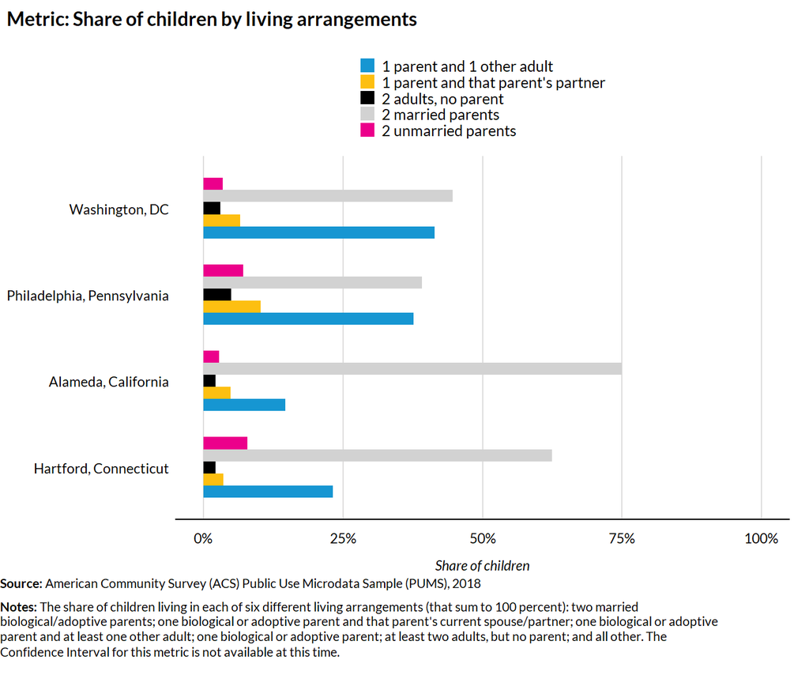

##### Subgroup

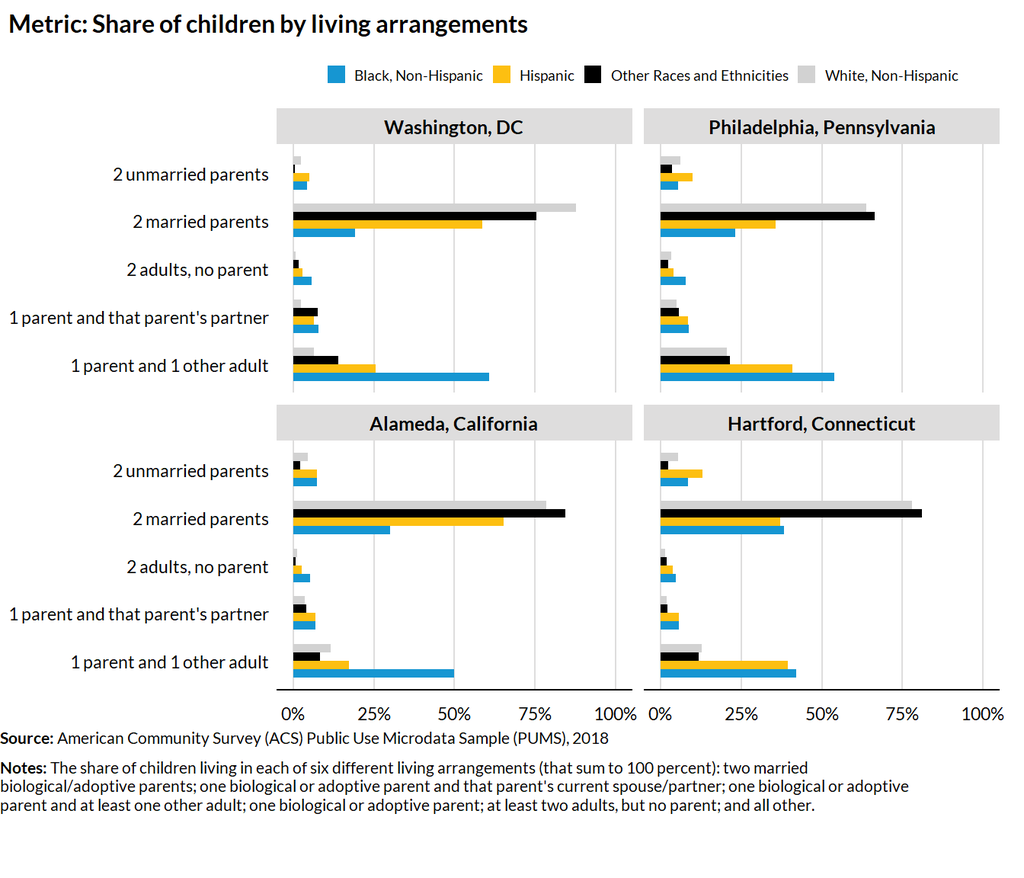

### Domain: Health

*Visit here for a thorough description of the metrics in this domain.*

#### Predictor: Access to and utilization of health services

##### Summary

Metric: Health Professional Shortage Area (1=yes/0=no) for primary care providers

|  | Washington, DC | Philadelphia, Pennsylvania | Alameda, California | Hartford, Connecticut |
| --- | --- | --- | --- | --- |
| HPSA | 1 | 0 | 1 | 0 |
| Quality | 3 | 1 | 3 | 1 |

**Source:** Health Resources and Services Administration Health Professional Shortage Areas for Primary Care, 2020

#### Predictor: Neonatal health

##### Summary

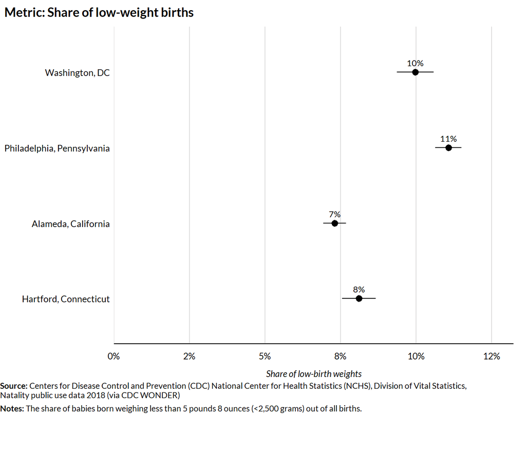

##### Subgroup

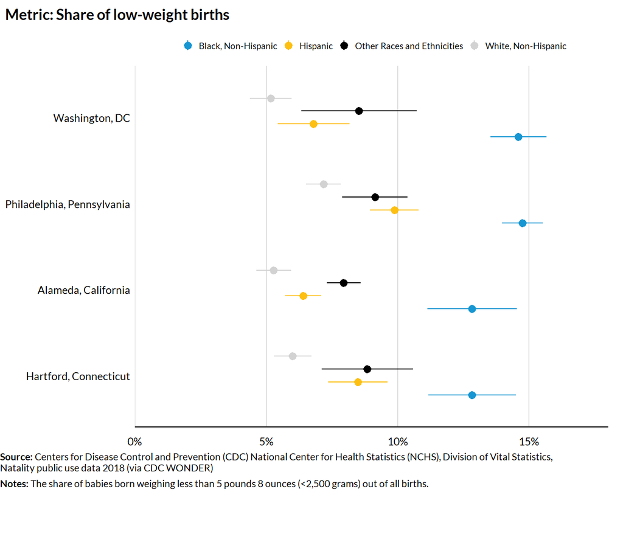

## Driver: Supportive Communities

### Domain: Local Governance

*Visit here for a thorough description of the metrics in this domain.*

#### Predictor: Political participation

##### Summary

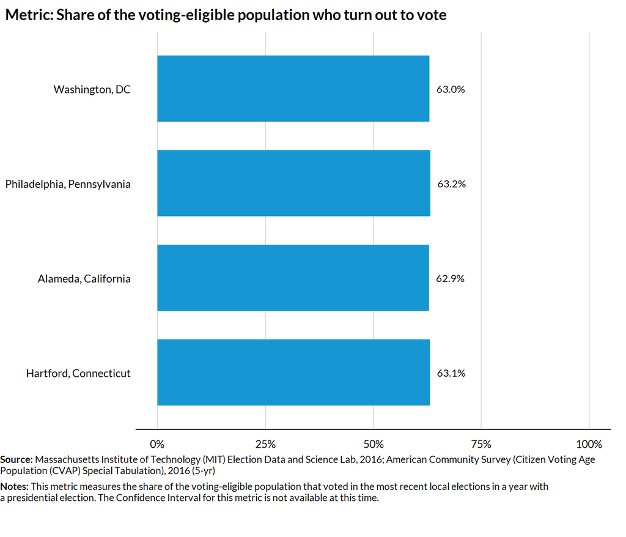

### Domain: Neighborhoods

*Visit here for a thorough description of the metrics in this domain.*

#### Predictor: Economic inclusion

##### Summary

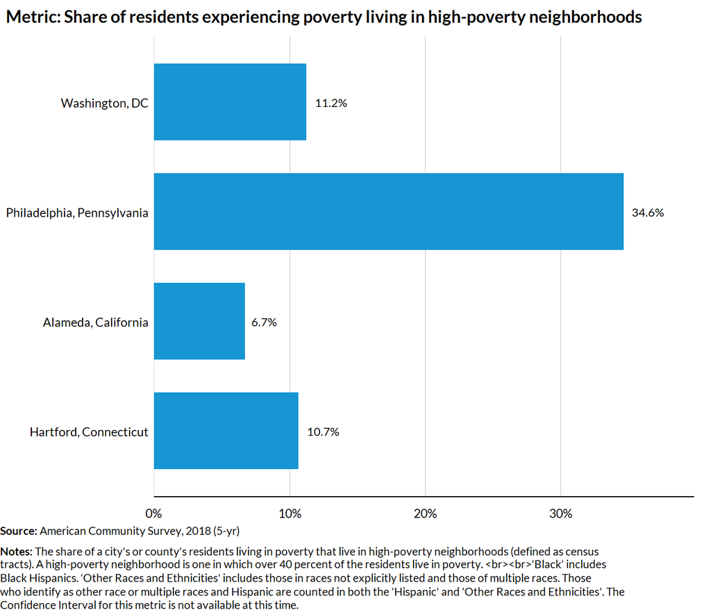

##### Subgroup

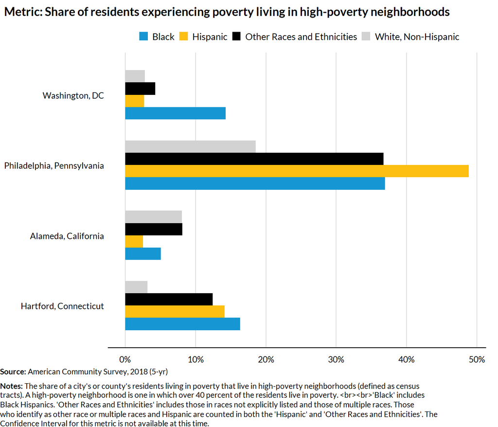

#### Predictor: Racial diversity

##### Summary

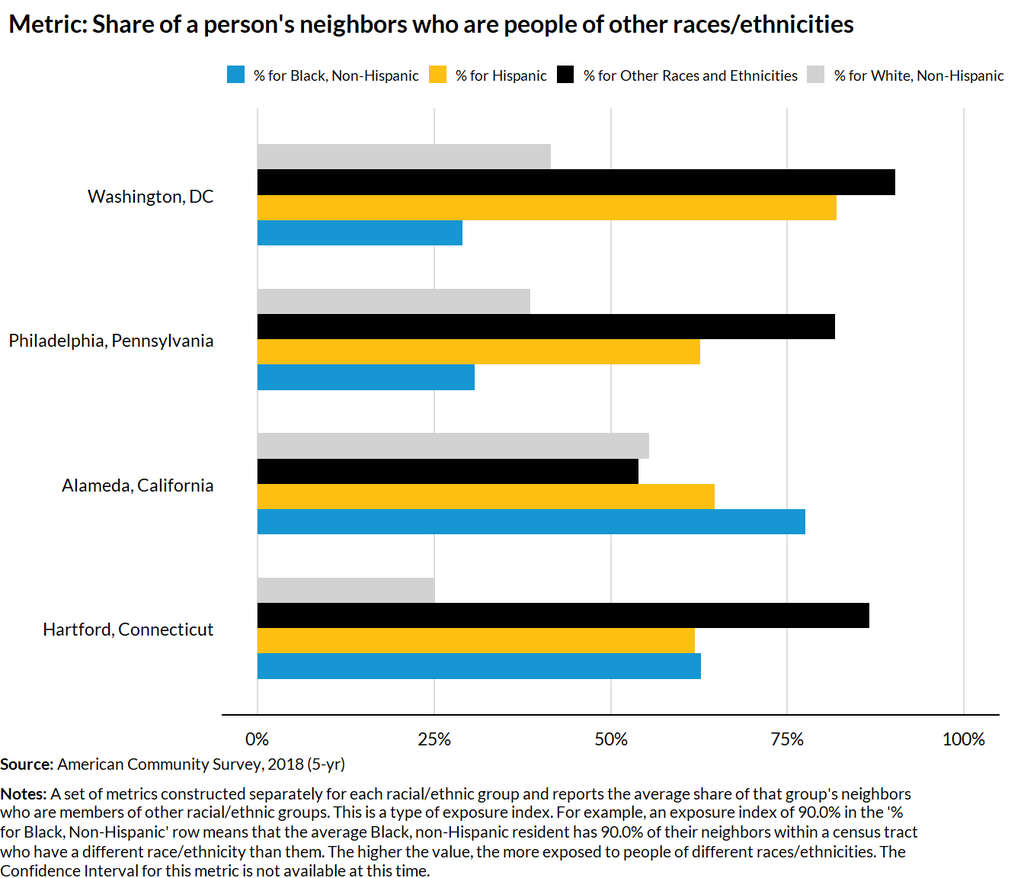

#### Predictor: Transportation access

##### Summary

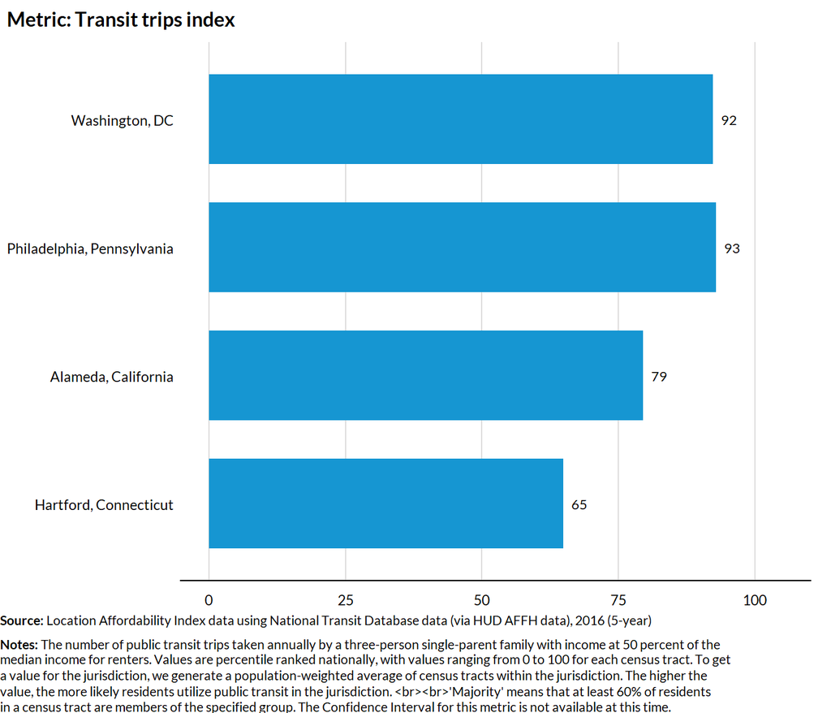

##### Sub-Area

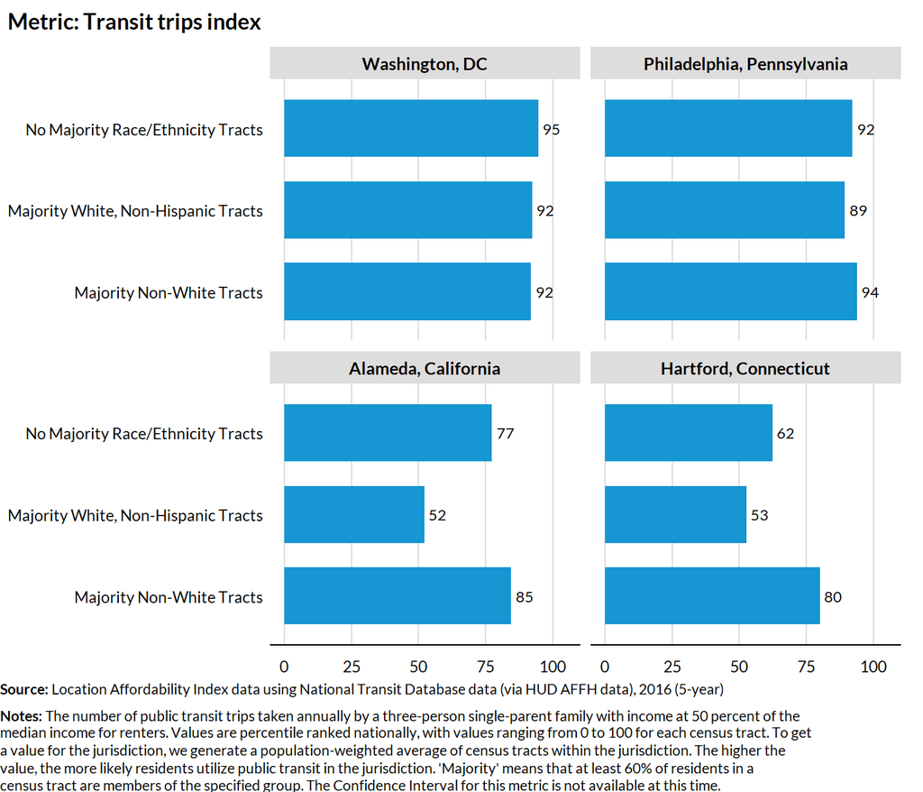

##### Summary

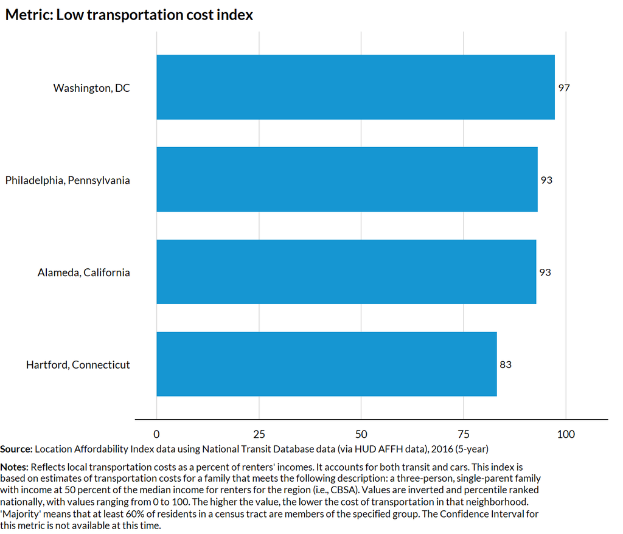

##### Sub-Area

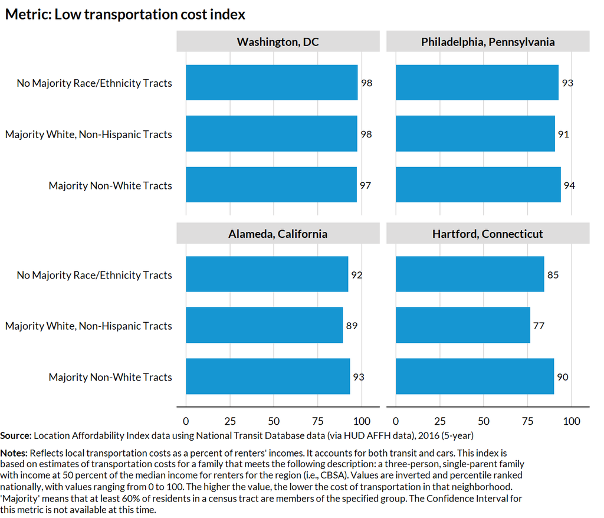

#### Predictor: Environmental quality

##### Summary

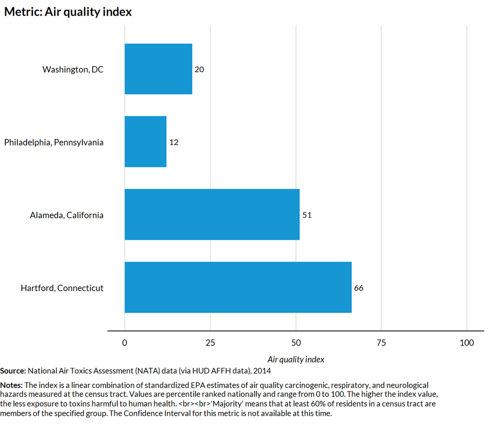

##### Sub-Area

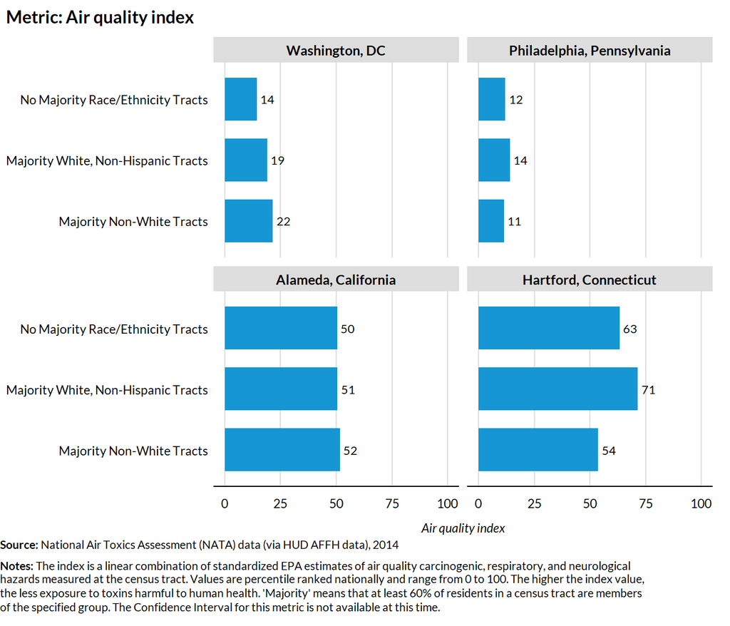

### Domain: Safety

*Visit here for a thorough description of the metrics in this domain.*

#### Predictor: Exposure to crime

##### Summary

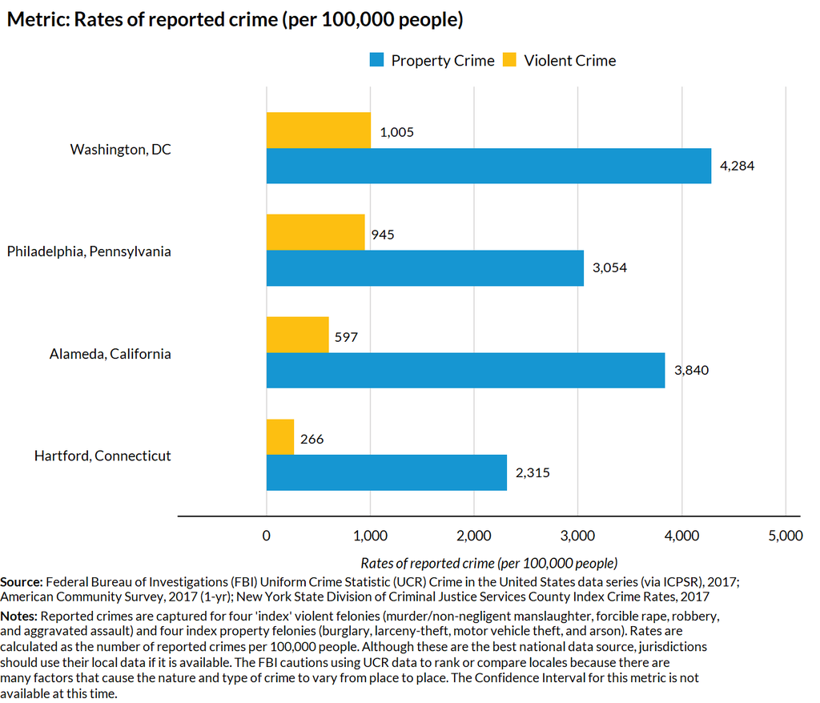

##### More Years

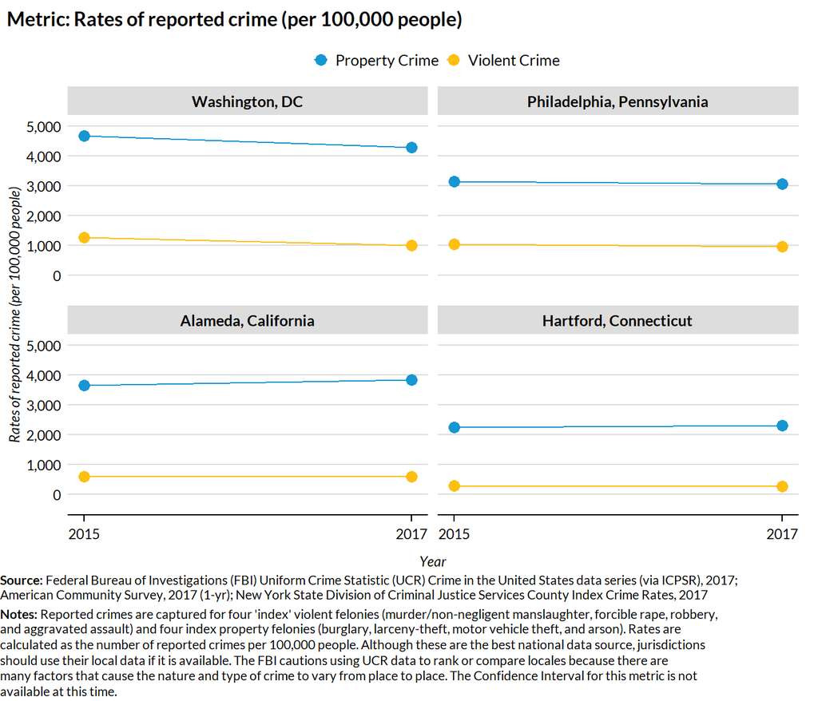

#### Predictor: Overly punitive policing

##### Summary

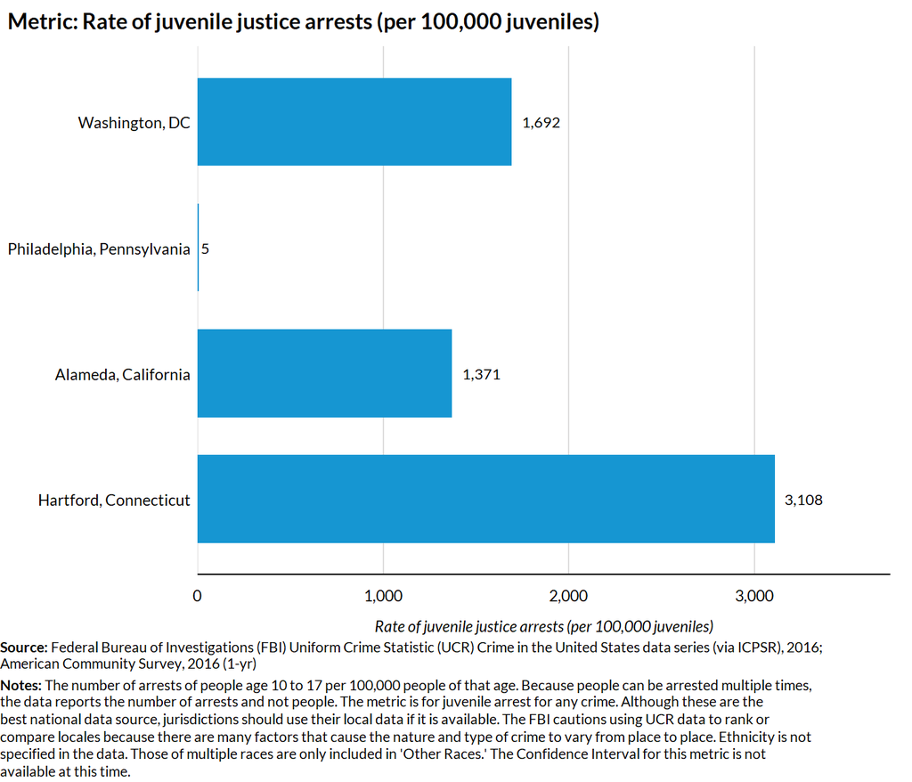

##### Subgroup

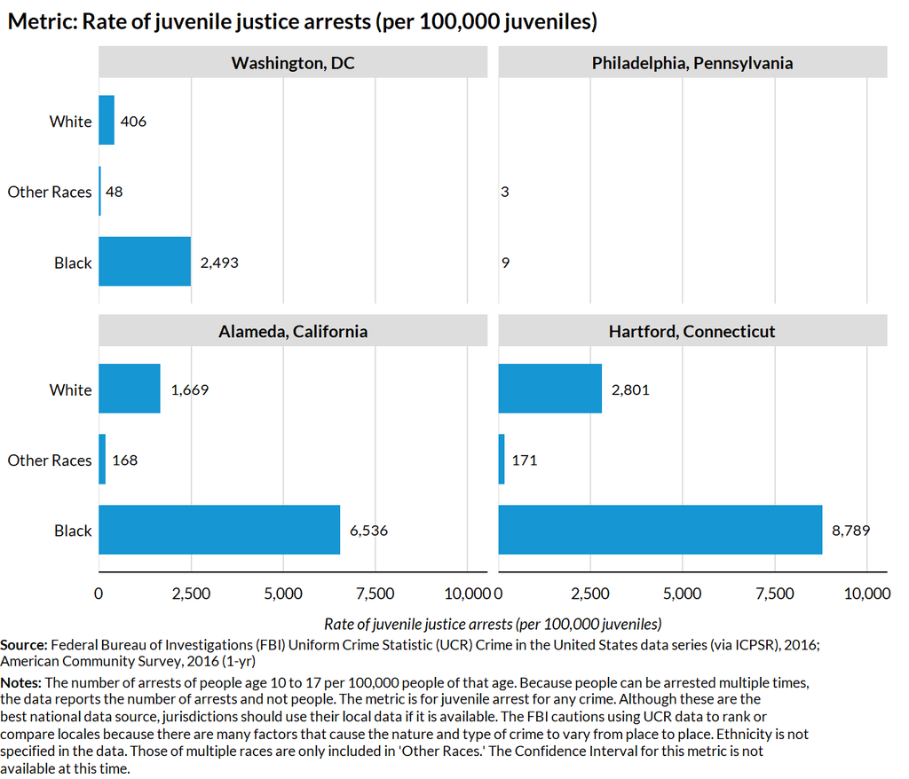

## Driver: Opportunities to Learn and Earn

### Domain: Education

*Visit here for a thorough description of the metrics in this domain.*

#### Predictor: Access to preschool

##### Summary

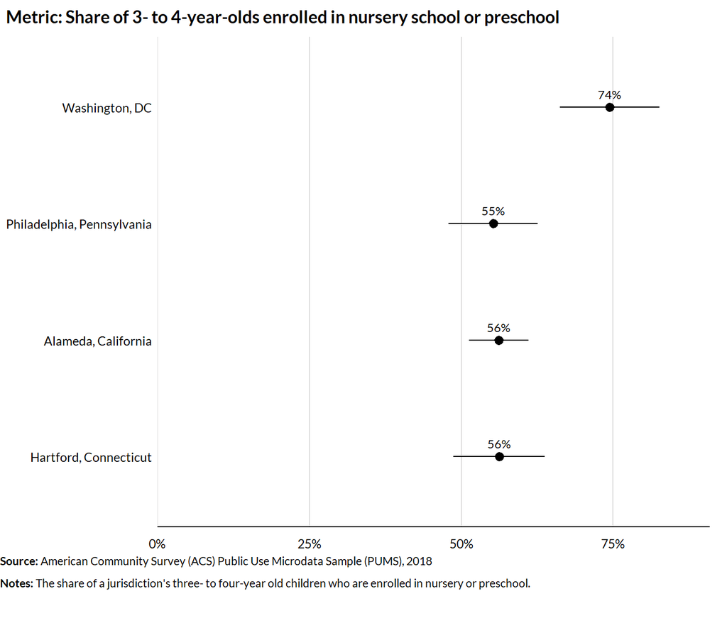

##### Subgroup

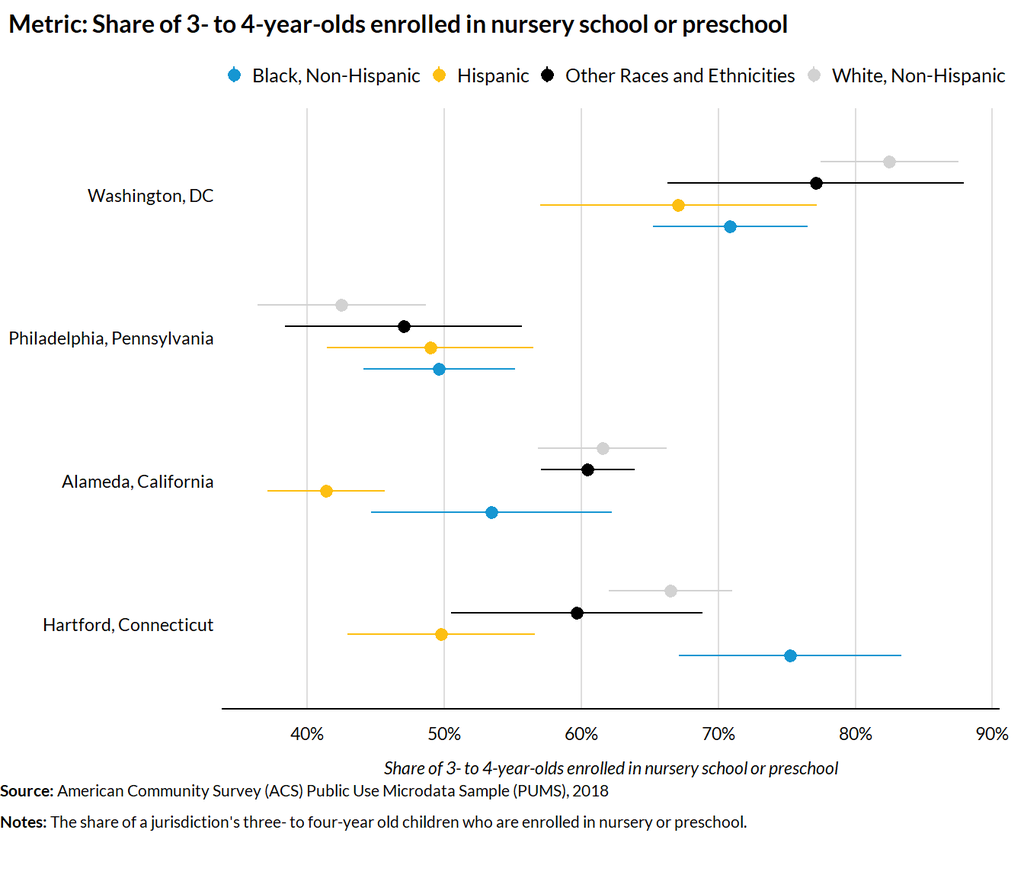